# Explore PAHO Data: Dengue

Eugene Joh

September 19, 2018

```r
if (!require(here)) install.packages("here")

source(here::here('01_load_packages.R'))

source(here::here('02_data_import.R'))
```

## Exploratory Data Analysis

Exploratory data analysis (EDA) is a fundamental (but not glorified) process within in the “data science” pipeline. By conducting this step in a cognizant manner can help in understanding the structure of the data, plan effective data cleaning, and processing for the analysis portion of the workflow. A good starting point on EDA is this [R for Data Science chapter](http://r4ds.had.co.nz/exploratory-data-analysis.html). To aid the process of EDA, this **parameterized R markdown** file accepts a (relatively) “tidy” dataset and will return some high level descriptives that are core to understanding the dataset.

- Data Type of each Column
- Number of Missing Observations `NA`
- Number of Unique Values

This can be easily be done by running the `glimpse` function from the `dplyr` package, but this markdown will provide some visualization to aid the understanding of the data. This will become useful when larger datasets (millions of rows and/or hundreds of columns) need to undergo some type of EDA.

## Data Types

```r
check_data_types <- function(input, name) { # input is params$i_data

  df_dat_type <- map_df(input, typeof) %>%
  gather(key = "Variable", value = "Data_Type") %>%
  left_join(
    map_df(input, ~sum(is.na(.))) %>%
      gather(key = "Variable", value = "N_Missing"),
    by = "Variable") %>%
  left_join(
    map_df(input, ~length(unique(.))) %>%
      gather(key = "Variable", value = "N_Unique"),
    by = "Variable") %>%
  mutate(
      N_row = nrow(input),
      Data_File = name,
      Variable = fct_inorder(Variable)
    )
}

df_dat_type <- check_data_types(params$i_data, params$i_names)
df_dat_type %>% add_kable()
```

| Variable | Data_Type | N_Missing | N_Unique | N_row | Data_File |
| --- | --- | --- | --- | --- | --- |
| Case Fatality Rate Percent | double | 0 | 75 | 1864 | d_fat |
| Code | integer | 0 | 50 | 1864 | d_fat |
| Country | character | 0 | 50 | 1864 | d_fat |
| Cases | integer | 6 | 841 | 1864 | d_fat |
| Muertes | integer | 3 | 82 | 1864 | d_fat |
| Pais o territorio | character | 0 | 50 | 1864 | d_fat |
| Tipo | character | 0 | 3 | 1864 | d_fat |
| Year vwPopulation per year | integer | 0 | 39 | 1864 | d_fat |
| Year | integer | 0 | 39 | 1864 | d_fat |

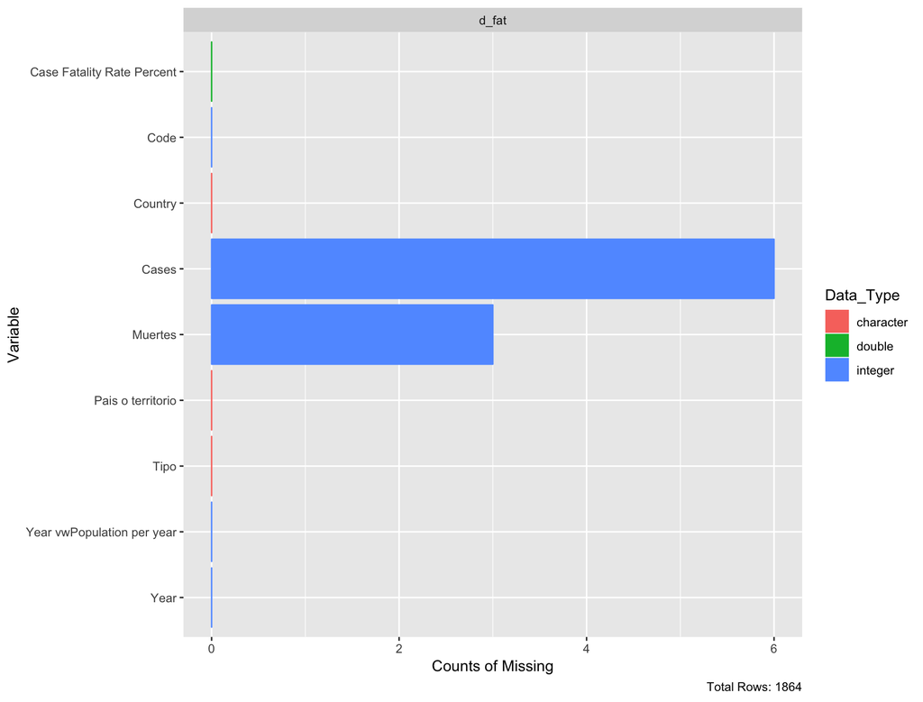

```r
df_dat_type %>%
  ggplot(aes(x = factor(fct_rev(fct_inorder(Variable))), y = N_Missing, fill = Data_Type, colour = Data_Type)) +
  geom_bar(stat='identity') +
  labs(x = "Variable", y = "Counts of Missing",
       caption = paste0("Total Rows: ", df_dat_type$N_row[1])) +
  coord_flip() +
  facet_wrap(~Data_File, scales = "free")
```

## Summary Statistics

### Continuous

```r
tidy_summary(params$i_data) %>% add_kable()
```

| variable | min | q25 | mean | median | q75 | max | sd | missing |
| --- | --- | --- | --- | --- | --- | --- | --- | --- |
| Case Fatality Rate Percent | 0 | 0 | 0.08 | 0.0 | 0.00 | 40 | 1.20 | 0 |
| Cases | 0 | 0 | 13396.24 | 29.5 | 2689.75 | 1649008 | 83946.49 | 6 |
| Code | 28 | 170 | 398.84 | 332.0 | 635.50 | 862 | 260.84 | 0 |
| Muertes | 0 | 0 | 6.17 | 0.0 | 0.00 | 863 | 41.04 | 3 |
| Year | 1980 | 1991 | 2000.08 | 2000.0 | 2010.00 | 2018 | 11.01 | 0 |
| Year vwPopulation per year | 1980 | 1991 | 2000.08 | 2000.0 | 2010.00 | 2018 | 11.01 | 0 |

### Categorical

```r
cat_list <- params$i_data %>% select_if(is.character) %>%
  map(~count(data.frame(variable=.x), variable))
```

````r
for (i in seq_along(cat_list)) {

  cat('#', names(cat_list)[i], '\n')
  cat('```{r}', '\n')

  # code here
  eval(cat_list[i])

  cat('\n')

  cat('```', '\n')

}
````

[output not shown]